# M200 Homework 4

Andrew Howe

May 2, 2015

# Part I : Further Reading

## Meta-Analysis

### Main Points

1. Null-Hypothesis Significane Testing (NHST) is often an incomplete, misleading metric.
- The null hypothesis can rarely be true in biology.
- NHST only tests one of the possible hypotheses that the data could support, rather than all relevant hypothesis, and often these other hypotheses are ignored.
- The NHST approach provides a binary assesment of a single theory, instead of a graded, probabilistic (and more realistic) assesment of possible explanations. 2a. Effect size with confidence intervals provides a better estimate across a range of possible hypotheses.
- Effect sizes and confidence intervals allow biologically realistic reasoning about the hypotheses the data may support.
- Effect sizes and confidence intervals position the results of a study for comparison with other similar studies in meta-analyses.
- Power analysis for NHST assists in study design due to its mathematical interconnections with effect size. 2b. There are a large number of methods to calculate effect sizes.
- Confusion exists with the term “effect size” due to its multiple meanings.
- Cohen’s *d* (or Hedges *g*), *r* statistics (measures of correlation) and odds ratios are good, general-purpose effect size measures.
- Correlation is not regression. Regression is for prediction, while correlation describes association.
- *r* is not simply equal to the square root of *R^2*.
3. Effect sizes should be corrected for bias, when it exists.
- Bias is caused by sampling errors or inherent features of the statistics employed.
- The problem is significantly more pronounced with small sample sizes.
- Biologists have never heard of *t* nor *f* distributions (now false.)
4. Heteroskedastic error or variance is likely to bias effect size and confidence interval measures.
- No generic solution exists.
- Try to linearize the data; for example, logrithms will transform exponential data into linear space, making the linear effect size and confidence interval calculations more accurate.
5. Effect size estimation for non-independent data (for example, messy field experiment data following individuals over years), is not impossible, but requires additional care. (Useful resources are provided.)
6. Effect size (and other statistical testing) must be interpreted in the context of their biological meaning.

### Meta-Analysis

Meta-analysis places the results from multiple studies deemed comparable by an analysis of their methods into a mathematical space where their results may be compared. Ideally, one will find that despite variance in confidence intervals, an effect of some significance lies within the 95% confidence intervals for all of the studies examined. Methods also exist to estimate the effect size and confidence intervals as though all the results were pooled into a single data pool (however, this requires some caution.)

### Multiple Regression

Covariation in data can have very large effects on effect sizes and confidence intervals, including complete reversal of the observed effect size. Generalized Linear Models (GLMs) provide a common (general) framework to examine covariance incorporating, e.g., ANCOVA, ANOVA, and regression. As GLMs represent an extension of multiple regression, it is possible to derive accurate estimations, provided certain caveats are met.

Of particular importance is simplification of the statistical model to its simplest viable form, which can be accomplished via the Akaike Information Criterian (AIC) approach. This approach often results in multiple predictors, and potentially multiple plausible models with a different subset of the predictive data. This approach is not foolproof.

## Multicolinearity

Multicolinearity occurs under a variety of different realistic experimental or analysis conditions. The term refers to the situation that arises when a pair of predictive variables vary together in a linear fashion. During linear regression model fitting, multicolinearity causes problems because the fitting technique attempts to find a solution to the multivariable model that minimizes the error in the model. When two or more of the variables included in the model colinearize, the solution is essentially unconstrained along the axis of colinearity, which means that a unique best solution for the fit parameters is effectively unavailable. Therefore a wide range of variables can satisfy the fitting technique, which leads to an unstable solution that may include a number of coefficients that are non-sensical upon examination. In one example provided by Slinker and Glantz (1985), the model fit provided a negative relationship between the measure of interest and a predictive variable, which is the opposite of what logic and prior knowledge dictate!

Multicolinearity arises either from experimental design or model construction. Ideal experimental design will yield only variables of interest with perfect control of all confounding variables. In practice, this can be quite difficult, especially if the system under study is not well understood or there is no way to control one of the counfounding variables without negatively affecting the experimental question. When a system is not well understood, the experiment may collect variables not previously known to colinearize; these must then be detected and handled during analysis and linear model construction. On the other hand, model construction itself can introduce colinearity when two measured variables (which may or may not already colinearize) are combined into an analytically-derived predictive variable.

Multicolinearity can be detected in several ways. One of the most important ways to detect multicolinearity (and other potential linear modeling problems) is examination of the model parameters and model structure. If the magnitude of a coefficient is significantly larger or smaller than one would expect, there might be a multicolinearity problem that requires further attention. Knowledge of maginitude or sign problems may come from prior experimental knowledge, theoretical knowledge or recognition of a mathematical phenomenon within the structure of the predictive equation itself. Slinker and Glantz provide an example where they recognize a harmonic damping feature in the response of their variable of interest in response to one of the predictive variables, and the coefficient assigned by the first model attempted is inappropriate because the oscillatory equation will not damp with the given parameter as their experimental system is known to do. Another method to detect multicolinearity is to manipulate the model structure and look for dramatic shifts in parameter value magnitude or sign changes. If a variable appears to be highly correlated with the variable being predicted, and yet the significance value of the coefficient is above a significance threshold, there might be a colinearity problem in the model. In all cases where these indicators suggest multicolinearity, further examination of the problem is required to determine the severity of the multicolinearity.

A variety of techniques can be employed to overcome serious multicolinearity problems. Multicolinearity does not prohibit prediction with a given model fit because the model remains constrained to the data despite the multicolinearity. However, if determination of the parameters is desired, the problem must be surmounted. Additional data can mitigate the problem by reducing the colinearity; for example, adding a new experimental condition that reduces the interaction will provide better constraints for the linear model fit procedure (the plane will be less able to rotate around and provide multiple solutions.) Removal of predictive variables can also assist, but it does change the model (this is equivalent to forcing a coefficient to zero) and it can be difficult to know which variables are appropriate to remove. If the multicolinearity appears to have arisen from a mathematical operation on one or more of the predictive variables, changing the operations that created the multicolinearity can overcome this problem. Scaling the predictive variables may also help to overcome correlations that exist between them. Slinker and Glantz highly recommend axes transformation in the form of principal components regression. This involves transforming the data correlations into another corridinate system, which minimizes the effect of the large correlation by allowing the axis with greatest variance to take precedence.

# Part II : Data Analysis

## Multiple Regression Tutorial

Let’s load and take a gander at some built in data about states.

```
## 'data.frame':    50 obs. of  8 variables:
##  $ Population: num  3615 365 2212 2110 21198 ...
##  $ Income    : num  3624 6315 4530 3378 5114 ...
##  $ Illiteracy: num  2.1 1.5 1.8 1.9 1.1 0.7 1.1 0.9 1.3 2 ...
##  $ Life Exp  : num  69 69.3 70.5 70.7 71.7 ...
##  $ Murder    : num  15.1 11.3 7.8 10.1 10.3 6.8 3.1 6.2 10.7 13.9 ...
##  $ HS Grad   : num  41.3 66.7 58.1 39.9 62.6 63.9 56 54.6 52.6 40.6 ...
##  $ Frost     : num  20 152 15 65 20 166 139 103 11 60 ...
##  $ Area      : num  50708 566432 113417 51945 156361 ...
```

Here, we’ll “fix” the labels, replacing spaces with periods.

**Before**

```
##  chr [1:8] "Population" "Income" "Illiteracy" "Life Exp" ...
```

**After**

```
##  chr [1:8] "Population" "Income" "Illiteracy" "Life.Exp" ...
```

The next phase will add a column called “Density” by combing some existing data for each state.

```
## 'data.frame':    50 obs. of  9 variables:
##  $ Population: num  3615 365 2212 2110 21198 ...
##  $ Income    : num  3624 6315 4530 3378 5114 ...
##  $ Illiteracy: num  2.1 1.5 1.8 1.9 1.1 0.7 1.1 0.9 1.3 2 ...
##  $ Life.Exp  : num  69 69.3 70.5 70.7 71.7 ...
##  $ Murder    : num  15.1 11.3 7.8 10.1 10.3 6.8 3.1 6.2 10.7 13.9 ...
##  $ HS.Grad   : num  41.3 66.7 58.1 39.9 62.6 63.9 56 54.6 52.6 40.6 ...
##  $ Frost     : num  20 152 15 65 20 166 139 103 11 60 ...
##  $ Area      : num  50708 566432 113417 51945 156361 ...
##  $ Density   : num  71.291 0.644 19.503 40.62 135.571 ...
```

Now let’s see some summary statistics!

```
##    Population        Income       Illiteracy       Life.Exp
##  Min.   :  365   Min.   :3098   Min.   :0.500   Min.   :67.96
##  1st Qu.: 1080   1st Qu.:3993   1st Qu.:0.625   1st Qu.:70.12
##  Median : 2838   Median :4519   Median :0.950   Median :70.67
##  Mean   : 4246   Mean   :4436   Mean   :1.170   Mean   :70.88
##  3rd Qu.: 4968   3rd Qu.:4814   3rd Qu.:1.575   3rd Qu.:71.89
##  Max.   :21198   Max.   :6315   Max.   :2.800   Max.   :73.60
##      Murder          HS.Grad          Frost             Area
##  Min.   : 1.400   Min.   :37.80   Min.   :  0.00   Min.   :  1049
##  1st Qu.: 4.350   1st Qu.:48.05   1st Qu.: 66.25   1st Qu.: 36985
##  Median : 6.850   Median :53.25   Median :114.50   Median : 54277
##  Mean   : 7.378   Mean   :53.11   Mean   :104.46   Mean   : 70736
##  3rd Qu.:10.675   3rd Qu.:59.15   3rd Qu.:139.75   3rd Qu.: 81162
##  Max.   :15.100   Max.   :67.30   Max.   :188.00   Max.   :566432
##     Density
##  Min.   :  0.6444
##  1st Qu.: 25.3352
##  Median : 73.0154
##  Mean   :149.2245
##  3rd Qu.:144.2828
##  Max.   :975.0033
```

And some correlations!

```
##             Population     Income   Illiteracy    Life.Exp     Murder
## Population  1.00000000  0.2082276  0.107622373 -0.06805195  0.3436428
## Income      0.20822756  1.0000000 -0.437075186  0.34025534 -0.2300776
## Illiteracy  0.10762237 -0.4370752  1.000000000 -0.58847793  0.7029752
## Life.Exp   -0.06805195  0.3402553 -0.588477926  1.00000000 -0.7808458
## Murder      0.34364275 -0.2300776  0.702975199 -0.78084575  1.0000000
## HS.Grad    -0.09848975  0.6199323 -0.657188609  0.58221620 -0.4879710
## Frost      -0.33215245  0.2262822 -0.671946968  0.26206801 -0.5388834
## Area        0.02254384  0.3633154  0.077261132 -0.10733194  0.2283902
## Density     0.24622789  0.3299683  0.009274348  0.09106176 -0.1850352
##                HS.Grad        Frost        Area      Density
## Population -0.09848975 -0.332152454  0.02254384  0.246227888
## Income      0.61993232  0.226282179  0.36331544  0.329968277
## Illiteracy -0.65718861 -0.671946968  0.07726113  0.009274348
## Life.Exp    0.58221620  0.262068011 -0.10733194  0.091061763
## Murder     -0.48797102 -0.538883437  0.22839021 -0.185035233
## HS.Grad     1.00000000  0.366779702  0.33354187 -0.088367214
## Frost       0.36677970  1.000000000  0.05922910  0.002276734
## Area        0.33354187  0.059229102  1.00000000 -0.341388515
## Density    -0.08836721  0.002276734 -0.34138851  1.000000000
```

Simplifying the problem a bit, let’s focus on life expectancy.

```
##      Murder  Illiteracy        Area  Population     Density       Frost
## -0.78084575 -0.58847793 -0.10733194 -0.06805195  0.09106176  0.26206801
##      Income     HS.Grad    Life.Exp
##  0.34025534  0.58221620  1.00000000
```

Murder rate has a fairly large negative correlation with life expectancy, as does illiteracy. High school graduation, income and frost (!?) also appear to positively correlate with life expectancy.

We can check this out visually with some dot-plots!

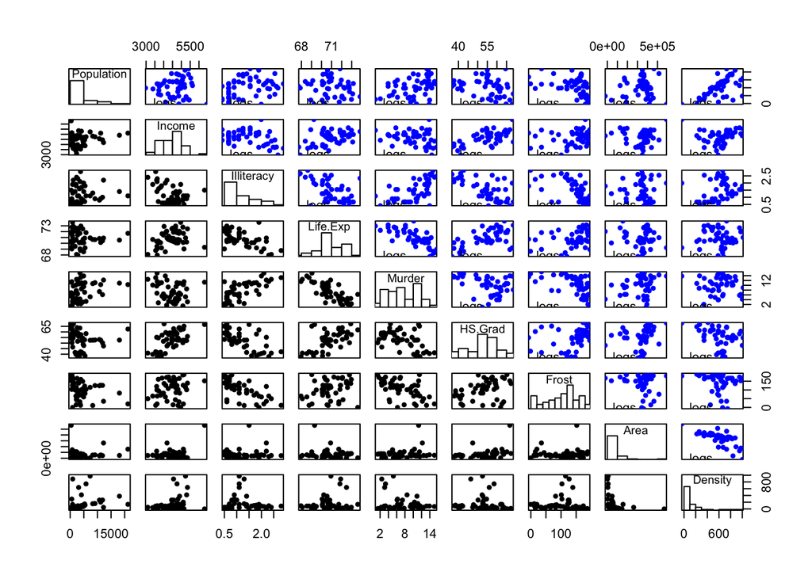

Neato! Along the diagonal are the attributes of the data set and histograms giving some rough idea of their distribution of variables. In the lower half of the panel, black dots represent pairs of data pulled from the data set and associated by state. The upper panel contains log-log plot versions of the data in the lower panels, which pulls outliers into the distribution, and can linearize non-linear (in particular exponential) relationships (or at least make them more obvious).

Next, we shall construct and iterate a linear model of the data to predict Life Expectancy, to see which variables are have the best correlations (and thus are most likely useful for prediction of Life Expectancy.)

```
##
## Call:
## lm(formula = Life.Exp ~ Population + Income + Illiteracy + Murder +
##     HS.Grad + Frost + Area + Density, data = st)
##
## Residuals:
##      Min       1Q   Median       3Q      Max
## -1.47514 -0.45887 -0.06352  0.59362  1.21823
##
## Coefficients:
##               Estimate Std. Error t value Pr(>|t|)
## (Intercept)  6.995e+01  1.843e+00  37.956  < 2e-16 ***
## Population   6.480e-05  3.001e-05   2.159   0.0367 *
## Income       2.701e-04  3.087e-04   0.875   0.3867
## Illiteracy   3.029e-01  4.024e-01   0.753   0.4559
## Murder      -3.286e-01  4.941e-02  -6.652 5.12e-08 ***
## HS.Grad      4.291e-02  2.332e-02   1.840   0.0730 .
## Frost       -4.580e-03  3.189e-03  -1.436   0.1585
## Area        -1.558e-06  1.914e-06  -0.814   0.4205
## Density     -1.105e-03  7.312e-04  -1.511   0.1385
## ---
## Signif. codes:  0 '***' 0.001 '**' 0.01 '*' 0.05 '.' 0.1 ' ' 1
##
## Residual standard error: 0.7337 on 41 degrees of freedom
## Multiple R-squared:  0.7501, Adjusted R-squared:  0.7013
## F-statistic: 15.38 on 8 and 41 DF,  p-value: 3.787e-10
```

```
##             Df Sum Sq Mean Sq F value   Pr(>F)
## Population   1  0.409   0.409   0.760  0.38849
## Income       1 11.595  11.595  21.541 3.53e-05 ***
## Illiteracy   1 19.421  19.421  36.081 4.23e-07 ***
## Murder       1 27.429  27.429  50.959 1.05e-08 ***
## HS.Grad      1  4.099   4.099   7.615  0.00861 **
## Frost        1  2.049   2.049   3.806  0.05792 .
## Area         1  0.001   0.001   0.002  0.96438
## Density      1  1.229   1.229   2.283  0.13847
## Residuals   41 22.068   0.538
## ---
## Signif. codes:  0 '***' 0.001 '**' 0.01 '*' 0.05 '.' 0.1 ' ' 1
```

```
##
## Call:
## lm(formula = Life.Exp ~ Population + Income + Illiteracy + Murder +
##     HS.Grad + Frost + Density, data = st)
##
## Residuals:
##      Min       1Q   Median       3Q      Max
## -1.50252 -0.40471 -0.06079  0.58682  1.43862
##
## Coefficients:
##               Estimate Std. Error t value Pr(>|t|)
## (Intercept)  7.094e+01  1.378e+00  51.488  < 2e-16 ***
## Population   6.249e-05  2.976e-05   2.100   0.0418 *
## Income       1.485e-04  2.690e-04   0.552   0.5840
## Illiteracy   1.452e-01  3.512e-01   0.413   0.6814
## Murder      -3.319e-01  4.904e-02  -6.768 3.12e-08 ***
## HS.Grad      3.746e-02  2.225e-02   1.684   0.0996 .
## Frost       -5.533e-03  2.955e-03  -1.873   0.0681 .
## Density     -7.995e-04  6.251e-04  -1.279   0.2079
## ---
## Signif. codes:  0 '***' 0.001 '**' 0.01 '*' 0.05 '.' 0.1 ' ' 1
##
## Residual standard error: 0.7307 on 42 degrees of freedom
## Multiple R-squared:  0.746,  Adjusted R-squared:  0.7037
## F-statistic: 17.63 on 7 and 42 DF,  p-value: 1.173e-10
```

```
## Analysis of Variance Table
##
## Model 1: Life.Exp ~ Population + Income + Illiteracy + Murder + HS.Grad +
##     Frost + Area + Density
## Model 2: Life.Exp ~ Population + Income + Illiteracy + Murder + HS.Grad +
##     Frost + Density
##   Res.Df    RSS Df Sum of Sq      F Pr(>F)
## 1     41 22.068
## 2     42 22.425 -1  -0.35639 0.6621 0.4205
```

```
##
## Call:
## lm(formula = Life.Exp ~ Population + Income + Murder + HS.Grad +
##     Frost + Density, data = st)
##
## Residuals:
##      Min       1Q   Median       3Q      Max
## -1.49555 -0.41246 -0.05336  0.58399  1.50535
##
## Coefficients:
##               Estimate Std. Error t value Pr(>|t|)
## (Intercept)  7.131e+01  1.042e+00  68.420  < 2e-16 ***
## Population   5.811e-05  2.753e-05   2.110   0.0407 *
## Income       1.324e-04  2.636e-04   0.502   0.6181
## Murder      -3.208e-01  4.054e-02  -7.912 6.32e-10 ***
## HS.Grad      3.499e-02  2.122e-02   1.649   0.1065
## Frost       -6.191e-03  2.465e-03  -2.512   0.0158 *
## Density     -7.324e-04  5.978e-04  -1.225   0.2272
## ---
## Signif. codes:  0 '***' 0.001 '**' 0.01 '*' 0.05 '.' 0.1 ' ' 1
##
## Residual standard error: 0.7236 on 43 degrees of freedom
## Multiple R-squared:  0.745,  Adjusted R-squared:  0.7094
## F-statistic: 20.94 on 6 and 43 DF,  p-value: 2.632e-11
```

```
##
## Call:
## lm(formula = Life.Exp ~ Population + Murder + HS.Grad + Frost +
##     Density, data = st)
##
## Residuals:
##      Min       1Q   Median       3Q      Max
## -1.56877 -0.40951 -0.04554  0.57362  1.54752
##
## Coefficients:
##               Estimate Std. Error t value Pr(>|t|)
## (Intercept)  7.142e+01  1.011e+00  70.665  < 2e-16 ***
## Population   6.083e-05  2.676e-05   2.273  0.02796 *
## Murder      -3.160e-01  3.910e-02  -8.083 3.07e-10 ***
## HS.Grad      4.233e-02  1.525e-02   2.776  0.00805 **
## Frost       -5.999e-03  2.414e-03  -2.485  0.01682 *
## Density     -5.864e-04  5.178e-04  -1.132  0.26360
## ---
## Signif. codes:  0 '***' 0.001 '**' 0.01 '*' 0.05 '.' 0.1 ' ' 1
##
## Residual standard error: 0.7174 on 44 degrees of freedom
## Multiple R-squared:  0.7435, Adjusted R-squared:  0.7144
## F-statistic: 25.51 on 5 and 44 DF,  p-value: 5.524e-12
```

```
##
## Call:
## lm(formula = Life.Exp ~ Population + Murder + HS.Grad + Frost,
##     data = st)
##
## Residuals:
##      Min       1Q   Median       3Q      Max
## -1.47095 -0.53464 -0.03701  0.57621  1.50683
##
## Coefficients:
##               Estimate Std. Error t value Pr(>|t|)
## (Intercept)  7.103e+01  9.529e-01  74.542  < 2e-16 ***
## Population   5.014e-05  2.512e-05   1.996  0.05201 .
## Murder      -3.001e-01  3.661e-02  -8.199 1.77e-10 ***
## HS.Grad      4.658e-02  1.483e-02   3.142  0.00297 **
## Frost       -5.943e-03  2.421e-03  -2.455  0.01802 *
## ---
## Signif. codes:  0 '***' 0.001 '**' 0.01 '*' 0.05 '.' 0.1 ' ' 1
##
## Residual standard error: 0.7197 on 45 degrees of freedom
## Multiple R-squared:  0.736,  Adjusted R-squared:  0.7126
## F-statistic: 31.37 on 4 and 45 DF,  p-value: 1.696e-12
```

```
## Analysis of Variance Table
##
## Model 1: Life.Exp ~ Population + Murder + HS.Grad + Frost
## Model 2: Life.Exp ~ Population + Murder + HS.Grad + Frost + Density
##   Res.Df    RSS Df Sum of Sq      F Pr(>F)
## 1     45 23.308
## 2     44 22.648  1   0.66005 1.2823 0.2636
```

```
##
## Call:
## lm(formula = Life.Exp ~ Murder + HS.Grad + Frost, data = st)
##
## Residuals:
##     Min      1Q  Median      3Q     Max
## -1.5015 -0.5391  0.1014  0.5921  1.2268
##
## Coefficients:
##              Estimate Std. Error t value Pr(>|t|)
## (Intercept) 71.036379   0.983262  72.246  < 2e-16 ***
## Murder      -0.283065   0.036731  -7.706 8.04e-10 ***
## HS.Grad      0.049949   0.015201   3.286  0.00195 **
## Frost       -0.006912   0.002447  -2.824  0.00699 **
## ---
## Signif. codes:  0 '***' 0.001 '**' 0.01 '*' 0.05 '.' 0.1 ' ' 1
##
## Residual standard error: 0.7427 on 46 degrees of freedom
## Multiple R-squared:  0.7127, Adjusted R-squared:  0.6939
## F-statistic: 38.03 on 3 and 46 DF,  p-value: 1.634e-12
```

This can be automated, although the tutorial author doesn’t like this idea. Automation is useful in the sense that when an algorithm makes a decision, it should not make decisions based on what it read last week, which means the results are replicable. Truly well designed algorithmic assistants can also parse massive amounts of data that a human observer could never manually examine.

However, placing blind trust in an algorithm, or failing to understand what it is doing (and therefore its strengths and limitations) is extremely bad practice. If the user cannot understand the algorithms behavior, it is best to perform the maniuplations by hand.

```
## Start:  AIC=-22.89
## Life.Exp ~ Population + Income + Illiteracy + Murder + HS.Grad +
##     Frost + Area + Density
##
##              Df Sum of Sq    RSS     AIC
## - Illiteracy  1    0.3050 22.373 -24.208
## - Area        1    0.3564 22.425 -24.093
## - Income      1    0.4120 22.480 -23.969
## <none>                    22.068 -22.894
## - Frost       1    1.1102 23.178 -22.440
## - Density     1    1.2288 23.297 -22.185
## - HS.Grad     1    1.8225 23.891 -20.926
## - Population  1    2.5095 24.578 -19.509
## - Murder      1   23.8173 45.886  11.707
##
## Step:  AIC=-24.21
## Life.Exp ~ Population + Income + Murder + HS.Grad + Frost + Area +
##     Density
##
##              Df Sum of Sq    RSS     AIC
## - Area        1    0.1427 22.516 -25.890
## - Income      1    0.2316 22.605 -25.693
## <none>                    22.373 -24.208
## - Density     1    0.9286 23.302 -24.174
## - HS.Grad     1    1.5218 23.895 -22.918
## - Population  1    2.2047 24.578 -21.509
## - Frost       1    3.1324 25.506 -19.656
## - Murder      1   26.7071 49.080  13.072
##
## Step:  AIC=-25.89
## Life.Exp ~ Population + Income + Murder + HS.Grad + Frost + Density
##
##              Df Sum of Sq    RSS     AIC
## - Income      1     0.132 22.648 -27.598
## - Density     1     0.786 23.302 -26.174
## <none>                    22.516 -25.890
## - HS.Grad     1     1.424 23.940 -24.824
## - Population  1     2.332 24.848 -22.962
## - Frost       1     3.304 25.820 -21.043
## - Murder      1    32.779 55.295  17.033
##
## Step:  AIC=-27.6
## Life.Exp ~ Population + Murder + HS.Grad + Frost + Density
##
##              Df Sum of Sq    RSS     AIC
## - Density     1     0.660 23.308 -28.161
## <none>                    22.648 -27.598
## - Population  1     2.659 25.307 -24.046
## - Frost       1     3.179 25.827 -23.030
## - HS.Grad     1     3.966 26.614 -21.529
## - Murder      1    33.626 56.274  15.910
##
## Step:  AIC=-28.16
## Life.Exp ~ Population + Murder + HS.Grad + Frost
##
##              Df Sum of Sq    RSS     AIC
## <none>                    23.308 -28.161
## - Population  1     2.064 25.372 -25.920
## - Frost       1     3.122 26.430 -23.877
## - HS.Grad     1     5.112 28.420 -20.246
## - Murder      1    34.816 58.124  15.528
```

```
##
## Call:
## lm(formula = Life.Exp ~ Population + Murder + HS.Grad + Frost,
##     data = st)
##
## Coefficients:
## (Intercept)   Population       Murder      HS.Grad        Frost
##   7.103e+01    5.014e-05   -3.001e-01    4.658e-02   -5.943e-03
```

```
##                   2.5 %       97.5 %
## (Intercept) 69.05717472 73.015582905
## Murder      -0.35700149 -0.209128849
## HS.Grad      0.01935043  0.080546980
## Frost       -0.01183825 -0.001985219
```

Next, we can try to predict life expectancy using the model and feeding it a few values.

```
##        1
## 69.77056
```

The plot below provides a visualization of the model fit. The residuals and the Q-Q plot both look good.

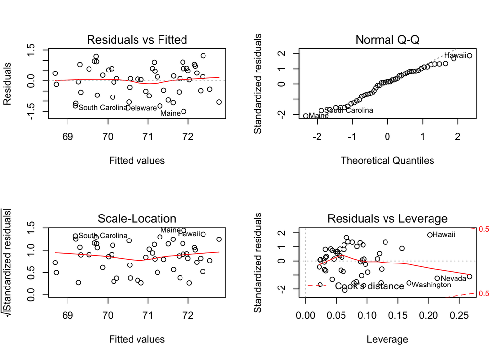

Accessing components of the model data is easy. First, we can select the parameters and then we can sort the residuals.

```
##  (Intercept)       Murder      HS.Grad        Frost
## 71.036378813 -0.283065168  0.049948704 -0.006911735
```

```
##          Maine       Delaware South Carolina    Mississippi        Arizona
##    -1.50150772    -1.23666537    -1.23162114    -1.11037437    -1.07681421
##     Washington  West Virginia        Montana         Alaska        Wyoming
##    -1.04976581    -1.04653483    -0.94669741    -0.80873734    -0.73927257
##         Nevada      Louisiana  New Hampshire   Pennsylvania  Massachusetts
##    -0.70837880    -0.56481311    -0.54666731    -0.51622769    -0.48235430
##     New Jersey         Oregon       Maryland        Georgia       Virginia
##    -0.46189744    -0.41031105    -0.32455693    -0.17498630    -0.06731035
## North Carolina   South Dakota        Indiana           Ohio        Florida
##    -0.05444180     0.05138438     0.05432904     0.07808745     0.10114571
##     New Mexico   Rhode Island       Oklahoma           Iowa          Idaho
##     0.10159299     0.10314800     0.18464735     0.19534036     0.23279723
##       Illinois        Alabama       Nebraska        Vermont    Connecticut
##     0.26968086     0.36325842     0.38328311     0.46958000     0.48472687
##       New York      Tennessee       Missouri      Wisconsin     California
##     0.53349703     0.58330361     0.59509781     0.60046076     0.60063821
##         Kansas           Utah       Kentucky      Minnesota       Colorado
##     0.61342480     0.72277428     0.79770164     0.80350324     0.90409006
##   North Dakota       Arkansas       Michigan          Texas         Hawaii
##     0.91307523     0.93888883     0.96231978     1.19135836     1.22680042
```

The following is a scaled version of the data.

```
##
## Call:
## lm(formula = scale(Life.Exp) ~ scale(Murder) + scale(HS.Grad) +
##     scale(Frost), data = st)
##
## Residuals:
##      Min       1Q   Median       3Q      Max
## -1.11853 -0.40156  0.07551  0.44111  0.91389
##
## Coefficients:
##                  Estimate Std. Error t value Pr(>|t|)
## (Intercept)    -4.604e-15  7.824e-02   0.000  1.00000
## scale(Murder)  -7.784e-01  1.010e-01  -7.706 8.04e-10 ***
## scale(HS.Grad)  3.005e-01  9.146e-02   3.286  0.00195 **
## scale(Frost)   -2.676e-01  9.477e-02  -2.824  0.00699 **
## ---
## Signif. codes:  0 '***' 0.001 '**' 0.01 '*' 0.05 '.' 0.1 ' ' 1
##
## Residual standard error: 0.5532 on 46 degrees of freedom
## Multiple R-squared:  0.7127, Adjusted R-squared:  0.6939
## F-statistic: 38.03 on 3 and 46 DF,  p-value: 1.634e-12
```

Here, we can check the result by manually scaling :

```
## [1] -0.778241
```

The following code block allows us to examine partial correlations.

```
## [1] -0.6999659
```

Now, let’s check out some air quality data.

```
##  (Intercept)      Solar.R         Wind         Temp        Month
## -58.05383883   0.04959683  -3.31650940   1.87087379  -2.99162786
```

```
## (Intercept)     Solar.R        Wind        Temp       Month
##  -58.053839    9.919365  -36.481603  149.669903  -17.949767
```

```
## [1] 47.10406
```

```
##        fit      lwr      upr
## 1 47.10406 41.10419 53.10393
```

```
##        fit      lwr      upr
## 1 47.10406 5.235759 88.97236
```

## Sepsis Data Analysis

### Multiple Regression Tutorial Applied to Sepsis

What are we looking at here anyway?

ApacheIII – Acute Physiology, Age, Chronic Health Evaluation; a higher score is worse

*pro-inflammatory markers*

IL6 – fever, inflamatory response IL8 – inflamation, immune response, chemotaxis inducer, ‘inflamation dispatcher’ (roughly, go to infection) TNFa – inflamation, regulation of immune cells, correlation with several human diseases LEP – leptin, wide ranging, inflammation

*cytokines*

CXCL1 – chemokine cytokine, mitogenic, cancer?, angiogenesis, inflammation IL1B – interleukin 1-beta; cytokine, involved in inflamation CCL3 – acute inflamation IL10 – anti-inflammatory cytokine IFNG – interferon; innate immune response compound CCL2 – supports immune response

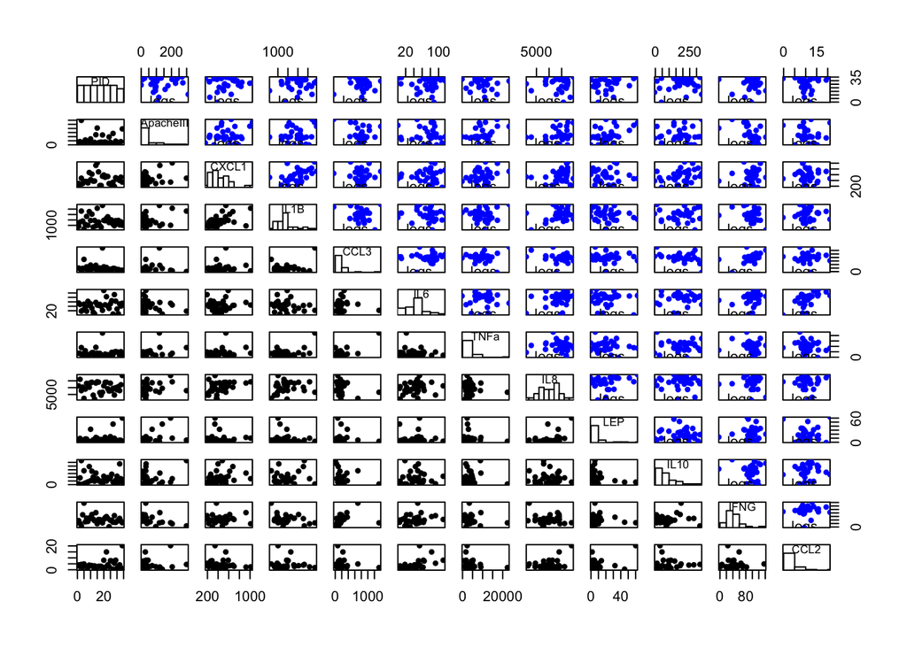

Here in the pairs plot, IL10 might have a correlation, but the data is fairly noisy. There aren’t any particularly striking correlations with the ApacheIII score.

Let’s test all the correlations all the pairs.

In the table below, all the correlations with Spearman and Pearson approaches are listed with their bootstrapped 95% CIs and p-values.

|  | p.Corr | p.CI.lo | p.CI.hi | p.Pval | p.Woo! | s.Corr | s.CI.lo | s.CI.hi | s.Pval | s.Woo! |
| --- | --- | --- | --- | --- | --- | --- | --- | --- | --- | --- |
| ApacheIII X CXCL1 | 0.307 | -0.1066 | 0.6638 | 0.0752 |  | 0.1051 | -0.2654 | 0.4444 | 0.5604 |  |
| ApacheIII X IL1B | 0.3673 | -0.2639 | 0.6566 | 0.0352 |  | 0.0159 | -0.3587 | 0.3726 | 0.9268 |  |
| ApacheIII X CCL3 | 0.0242 | -0.452 | 0.4848 | 0.9001 |  | -0.1449 | -0.4914 | 0.2392 | 0.4147 |  |
| ApacheIII X IL6 | -0.1971 | -0.438 | 0.1094 | 0.2529 |  | 8e-04 | -0.3661 | 0.3716 | 0.9969 |  |
| ApacheIII X TNFa | 0.3528 | -0.0509 | 0.6636 | 0.0487 |  | 0.1869 | -0.2014 | 0.528 | 0.2898 |  |
| ApacheIII X IL8 | 0.1862 | -0.1626 | 0.541 | 0.2939 |  | 0.1966 | -0.1647 | 0.5184 | 0.266 |  |
| ApacheIII X LEP | 0.4491 | 0.088 | 0.8471 | 0.0206 | ! | 0.4329 | 0.1003 | 0.673 | 0.0116 | ! |
| ApacheIII X IL10 | 0.2399 | -0.3374 | 0.6557 | 0.1576 |  | -0.0688 | -0.4329 | 0.2988 | 0.6936 |  |
| ApacheIII X IFNG | -0.4065 | -0.6968 | -0.0823 | 0.0295 |  | -0.5336 | -0.7912 | -0.1722 | 0.0018 |  |
| ApacheIII X CCL2 | 0.1559 | -0.3743 | 0.5866 | 0.3398 |  | -0.0982 | -0.4663 | 0.2765 | 0.58 |  |
| CXCL1 X IL1B | 0.5124 | 0.139 | 0.7917 | 0.0025 | ! | 0.5007 | 0.1646 | 0.7527 | 0.0018 | ! |
| CXCL1 X CCL3 | 0.08 | -0.2471 | 0.3346 | 0.6374 |  | 0.0026 | -0.3478 | 0.3411 | 0.9871 |  |
| CXCL1 X IL6 | 0.0593 | -0.2557 | 0.3048 | 0.7344 |  | -0.0564 | -0.3836 | 0.2758 | 0.7438 |  |
| CXCL1 X TNFa | 0.2337 | -0.0256 | 0.5375 | 0.1511 |  | 0.2067 | -0.1373 | 0.5106 | 0.2381 |  |
| CXCL1 X IL8 | 0.3494 | 0.0687 | 0.6112 | 0.0412 | ! | 0.3662 | 0.0028 | 0.6658 | 0.0314 | ! |
| CXCL1 X LEP | -0.0911 | -0.2613 | 0.1879 | 0.5952 |  | -0.1251 | -0.4819 | 0.2356 | 0.4833 |  |
| CXCL1 X IL10 | 0.2846 | 0.0569 | 0.5585 | 0.1 | !? | 0.3668 | 0.0536 | 0.6216 | 0.0337 | ! |
| CXCL1 X IFNG | 0.0872 | -0.2436 | 0.5305 | 0.6063 |  | 0.16 | -0.2023 | 0.5048 | 0.3624 |  |
| CXCL1 X CCL2 | -0.071 | -0.2743 | 0.2043 | 0.6732 |  | -0.0778 | -0.3916 | 0.2482 | 0.6621 |  |
| IL1B X CCL3 | 0.254 | -0.5398 | 0.7055 | 0.1354 |  | -0.1276 | -0.517 | 0.2859 | 0.462 |  |
| IL1B X IL6 | -0.1829 | -0.4368 | 0.0851 | 0.3033 |  | -0.1832 | -0.4975 | 0.1622 | 0.2919 |  |
| IL1B X TNFa | 0.4293 | -0.3267 | 0.738 | 0.0186 |  | -0.0558 | -0.4156 | 0.303 | 0.7527 |  |
| IL1B X IL8 | 0.1976 | -0.1632 | 0.5576 | 0.2597 |  | 0.2862 | -0.1162 | 0.6191 | 0.0999 |  |
| IL1B X LEP | -0.1843 | -0.3462 | 0.0496 | 0.2935 |  | -0.196 | -0.5008 | 0.135 | 0.2649 |  |
| IL1B X IL10 | 0.1947 | -0.2805 | 0.6192 | 0.2714 |  | 0.1285 | -0.2728 | 0.5223 | 0.4643 |  |
| IL1B X IFNG | -0.293 | -0.5363 | 0.1453 | 0.0938 |  | -0.1068 | -0.4629 | 0.2938 | 0.5518 |  |
| IL1B X CCL2 | -0.0549 | -0.2509 | 0.2473 | 0.7468 |  | 0.1123 | -0.2263 | 0.4401 | 0.5263 |  |
| CCL3 X IL6 | -0.0559 | -0.2764 | 0.3331 | 0.7265 |  | 0.0512 | -0.3088 | 0.381 | 0.7681 |  |
| CCL3 X TNFa | 0.7271 | -0.3236 | 0.9309 | 0.0135 |  | 0.0069 | -0.3685 | 0.3733 | 0.9696 |  |
| CCL3 X IL8 | -0.242 | -0.4901 | 0.2363 | 0.167 |  | -0.1111 | -0.4463 | 0.2726 | 0.528 |  |
| CCL3 X LEP | -0.0719 | -0.2237 | 0.3597 | 0.6026 |  | -0.0344 | -0.3835 | 0.3242 | 0.8471 |  |
| CCL3 X IL10 | -0.1905 | -0.522 | 0.2822 | 0.236 |  | -0.3137 | -0.6426 | 0.0851 | 0.0728 |  |
| CCL3 X IFNG | 0.2894 | -0.1642 | 0.9017 | 0.0704 |  | 0.4882 | 0.1419 | 0.7531 | 0.0028 | ! |
| CCL3 X CCL2 | -0.0996 | -0.2525 | 0.2225 | 0.4799 |  | -0.0026 | -0.3607 | 0.35 | 0.9854 |  |
| IL6 X TNFa | -0.155 | -0.3704 | 0.2493 | 0.3524 |  | -0.0234 | -0.4052 | 0.3462 | 0.8946 |  |
| IL6 X IL8 | 0.2248 | -0.1101 | 0.5348 | 0.2042 |  | 0.3042 | -0.0209 | 0.5801 | 0.0769 |  |
| IL6 X LEP | -0.0575 | -0.3956 | 0.2695 | 0.732 |  | 0.0335 | -0.3275 | 0.4165 | 0.85 |  |
| IL6 X IL10 | 0.0158 | -0.2894 | 0.3412 | 0.9316 |  | 0.1584 | -0.2143 | 0.4878 | 0.3769 |  |
| IL6 X IFNG | 0.2085 | -0.0089 | 0.4465 | 0.2312 |  | 0.222 | -0.1101 | 0.5061 | 0.2041 |  |
| IL6 X CCL2 | 0.4926 | 0.3191 | 0.7463 | 0.0043 | ! | 0.5823 | 0.2464 | 0.7969 | 3e-04 | ! |
| TNFa X IL8 | -0.1642 | -0.3888 | 0.1485 | 0.3535 |  | -0.1245 | -0.4297 | 0.1998 | 0.4864 |  |
| TNFa X LEP | -0.1262 | -0.2439 | 0.086 | 0.3395 |  | 0.0353 | -0.3056 | 0.3697 | 0.8443 |  |
| TNFa X IL10 | 0.0166 | -0.2984 | 0.6143 | 0.9209 |  | 0.0888 | -0.3105 | 0.4656 | 0.6125 |  |
| TNFa X IFNG | -0.1311 | -0.4331 | 0.2921 | 0.3869 |  | -0.2153 | -0.5512 | 0.1489 | 0.2167 |  |
| TNFa X CCL2 | -0.1837 | -0.3354 | 0.0215 | 0.1689 |  | -0.2358 | -0.5399 | 0.1258 | 0.1837 |  |
| IL8 X LEP | 0.4035 | 0.0448 | 0.6557 | 0.0176 | ! | 0.3063 | -0.068 | 0.6047 | 0.0809 |  |
| IL8 X IL10 | -0.1114 | -0.3772 | 0.1939 | 0.5343 |  | -0.0063 | -0.3362 | 0.3142 | 0.9695 |  |
| IL8 X IFNG | -0.1703 | -0.5203 | 0.3562 | 0.34 |  | 0.0463 | -0.3359 | 0.4494 | 0.7855 |  |
| IL8 X CCL2 | 0.335 | -0.2123 | 0.6121 | 0.0539 |  | 0.0041 | -0.3325 | 0.3404 | 0.984 |  |
| LEP X IL10 | -0.1956 | -0.3463 | 0.0118 | 0.2507 |  | -0.0179 | -0.3497 | 0.334 | 0.9236 |  |
| LEP X IFNG | -0.1113 | -0.3045 | 0.2226 | 0.4691 |  | -0.0157 | -0.351 | 0.341 | 0.934 |  |
| LEP X CCL2 | 0.4077 | -0.3942 | 0.8592 | 0.0392 |  | 0.0017 | -0.3985 | 0.3916 | 0.9923 |  |
| IL10 X IFNG | 0.1453 | -0.3315 | 0.5496 | 0.3975 |  | 0.1511 | -0.2386 | 0.5207 | 0.3916 |  |
| IL10 X CCL2 | -0.0237 | -0.2049 | 0.3325 | 0.8892 |  | 0.229 | -0.1241 | 0.5287 | 0.1944 |  |
| IFNG X CCL2 | 0.0156 | -0.2271 | 0.3238 | 0.9214 |  | 0.182 | -0.182 | 0.5121 | 0.3011 |  |

That’s a bit disappointing. (both the corerlations and the format.) In terms of ApacheIII, the only IFNG and LEP don’t span zero in the estimation of the 95% CI.

Let’s try an automated model search on everything and see what happens.

```
##
## Call:
## lm(formula = ApacheIII ~ CXCL1 + IL1B + CCL3 + IL6 + TNFa + IL8 +
##     LEP + IL10 + IFNG + CCL2, data = sepsisData)
##
## Residuals:
##     Min      1Q  Median      3Q     Max
## -61.816 -23.623  -4.823  25.462 106.165
##
## Coefficients:
##              Estimate Std. Error t value Pr(>|t|)
## (Intercept)  7.721819  35.486417   0.218  0.82966
## CXCL1        0.086353   0.058551   1.475  0.15381
## IL1B         0.007974   0.012171   0.655  0.51888
## CCL3        -0.043714   0.072681  -0.601  0.55342
## IL6         -0.165996   0.444062  -0.374  0.71197
## TNFa         0.006256   0.003995   1.566  0.13099
## IL8         -0.002873   0.002785  -1.032  0.31303
## LEP          2.982633   0.853187   3.496  0.00195 **
## IL10         0.206048   0.125806   1.638  0.11507
## IFNG        -0.783899   0.510436  -1.536  0.13824
## CCL2         1.619620   2.771249   0.584  0.56462
## ---
## Signif. codes:  0 '***' 0.001 '**' 0.01 '*' 0.05 '.' 0.1 ' ' 1
##
## Residual standard error: 44.48 on 23 degrees of freedom
## Multiple R-squared:  0.676,  Adjusted R-squared:  0.5352
## F-statistic: 4.799 on 10 and 23 DF,  p-value: 0.0009079
```

```
## Start:  AIC=266.77
## ApacheIII ~ CXCL1 + IL1B + CCL3 + IL6 + TNFa + IL8 + LEP + IL10 +
##     IFNG + CCL2
##
##         Df Sum of Sq   RSS    AIC
## - IL6    1     276.4 45777 264.98
## - CCL2   1     675.7 46176 265.27
## - CCL3   1     715.6 46216 265.30
## - IL1B   1     849.1 46349 265.40
## - IL8    1    2104.9 47605 266.31
## <none>               45500 266.77
## - CXCL1  1    4303.1 49804 267.84
## - IFNG   1    4665.8 50166 268.09
## - TNFa   1    4851.9 50352 268.21
## - IL10   1    5306.6 50807 268.52
## - LEP    1   24176.8 69677 279.26
##
## Step:  AIC=264.98
## ApacheIII ~ CXCL1 + IL1B + CCL3 + TNFa + IL8 + LEP + IL10 + IFNG +
##     CCL2
##
##         Df Sum of Sq   RSS    AIC
## - CCL2   1       405 46182 263.27
## - CCL3   1       805 46582 263.57
## - IL1B   1      1338 47114 263.95
## - IL8    1      2688 48465 264.92
## <none>               45777 264.98
## - CXCL1  1      4081 49858 265.88
## - IFNG   1      4700 50477 266.30
## - TNFa   1      4910 50687 266.44
## - IL10   1      5232 51008 266.65
## - LEP    1     32808 78585 281.35
##
## Step:  AIC=263.28
## ApacheIII ~ CXCL1 + IL1B + CCL3 + TNFa + IL8 + LEP + IL10 + IFNG
##
##         Df Sum of Sq   RSS    AIC
## - CCL3   1       753 46935 261.83
## - IL1B   1      1446 47628 262.32
## - IL8    1      2347 48528 262.96
```

[output cut: 27 more lines]

```
## - TNFa   1      8937 56763 264.29
## - IL10   1     11382 59208 265.72
## - IFNG   1     19994 67820 270.34
## - LEP    1     36722 84548 277.84
##
## Step:  AIC=259.56
## ApacheIII ~ CXCL1 + TNFa + LEP + IL10 + IFNG
##
##         Df Sum of Sq   RSS    AIC
## <none>               49390 259.56
## - CXCL1  1      5884 55274 261.38
## - TNFa   1     12513 61903 265.24
## - IL10   1     13414 62804 265.73
## - IFNG   1     18486 67876 268.37
## - LEP    1     37202 86591 276.65
```

```
##
## Call:
## lm(formula = ApacheIII ~ CXCL1 + TNFa + LEP + IL10 + IFNG, data = sepsisData)
##
## Coefficients:
## (Intercept)        CXCL1         TNFa          LEP         IL10
##   -2.572698     0.076374     0.005375     2.764960     0.276150
##        IFNG
##   -1.012413
```

```
##
## Call:
## lm(formula = ApacheIII ~ CXCL1 + IL10 + IFNG + TNFa + LEP, data = sepsisData)
##
## Residuals:
##     Min      1Q  Median      3Q     Max
## -54.898 -26.940  -9.699  18.188 119.273
##
## Coefficients:
##              Estimate Std. Error t value Pr(>|t|)
## (Intercept) -2.572698  24.599435  -0.105   0.9175
## CXCL1        0.076374   0.041817   1.826   0.0785 .
## IL10         0.276150   0.100138   2.758   0.0101 *
## IFNG        -1.012413   0.312735  -3.237   0.0031 **
## TNFa         0.005375   0.002018   2.663   0.0127 *
## LEP          2.764960   0.602070   4.592 8.45e-05 ***
## ---
## Signif. codes:  0 '***' 0.001 '**' 0.01 '*' 0.05 '.' 0.1 ' ' 1
##
## Residual standard error: 42 on 28 degrees of freedom
## Multiple R-squared:  0.6483, Adjusted R-squared:  0.5855
## F-statistic: 10.32 on 5 and 28 DF,  p-value: 1.092e-05
```

```
##                     2.5 %      97.5 %
## (Intercept) -52.962355604 47.81695964
## CXCL1        -0.009284212  0.16203168
## IL10          0.071027336  0.48127340
## IFNG         -1.653020646 -0.37180508
## TNFa          0.001241111  0.00950867
## LEP           1.531676409  3.99824413
```

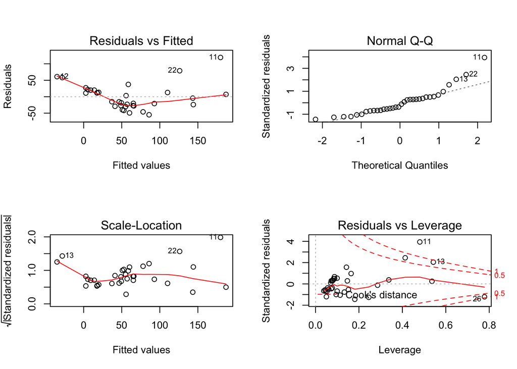

```
##
## Call:
## lm(formula = ApacheIII ~ CXCL1 + IL1B + CCL3 + IL10 + IFNG +
##     CCL2, data = sepsisData)
##
## Residuals:
##    Min     1Q Median     3Q    Max
## -66.52 -38.46 -10.24  26.36 140.78
##
## Coefficients:
##              Estimate Std. Error t value Pr(>|t|)
## (Intercept) 34.464133  34.213716   1.007  0.32272
## CXCL1        0.104111   0.063688   1.635  0.11372
## IL1B        -0.004617   0.013543  -0.341  0.73578
## CCL3         0.073959   0.050473   1.465  0.15438
## IL10         0.257956   0.139600   1.848  0.07561 .
## IFNG        -1.570540   0.508626  -3.088  0.00463 **
## CCL2         3.613088   2.483350   1.455  0.15722
## ---
## Signif. codes:  0 '***' 0.001 '**' 0.01 '*' 0.05 '.' 0.1 ' ' 1
##
## Residual standard error: 55.14 on 27 degrees of freedom
## Multiple R-squared:  0.4154, Adjusted R-squared:  0.2855
## F-statistic: 3.197 on 6 and 27 DF,  p-value: 0.01674
```

```
## Start:  AIC=278.84
## ApacheIII ~ CXCL1 + IL1B + CCL3 + IL10 + IFNG + CCL2
##
##         Df Sum of Sq    RSS    AIC
## - IL1B   1     353.5  82457 276.99
## <none>                82103 278.84
## - CCL2   1    6436.9  88540 279.40
## - CCL3   1    6529.2  88632 279.44
## - CXCL1  1    8125.8  90229 280.05
## - IL10   1   10382.8  92486 280.89
## - IFNG   1   28993.2 111096 287.12
##
## Step:  AIC=276.98
## ApacheIII ~ CXCL1 + CCL3 + IL10 + IFNG + CCL2
##
##         Df Sum of Sq    RSS    AIC
## <none>                82457 276.99
## - CCL2   1      6319  88776 277.50
## - CCL3   1      6624  89080 277.61
## - CXCL1  1      8998  91455 278.51
## - IL10   1     10102  92558 278.91
## - IFNG   1     36304 118760 287.39
```

```
##
## Call:
## lm(formula = ApacheIII ~ CXCL1 + CCL3 + IL10 + IFNG + CCL2, data = sepsisData)
##
## Coefficients:
## (Intercept)        CXCL1         CCL3         IL10         IFNG
##    30.03040      0.09246      0.06596      0.24534     -1.47649
##        CCL2
##     3.57656
```

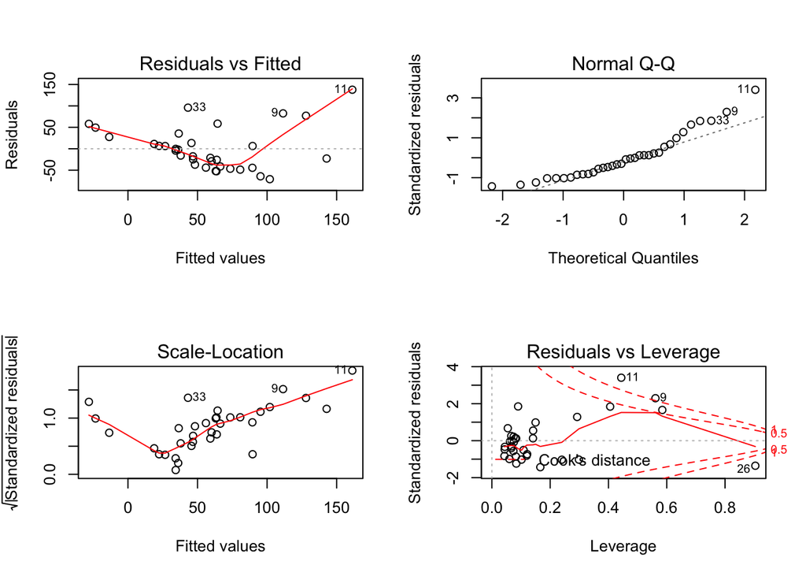

```
##                    2.5 %     97.5 %
## (Intercept) -33.76220770 93.8229990
## CXCL1        -0.01589053  0.2008192
## CCL3         -0.02413038  0.1560559
## IL10         -0.02600168  0.5166763
## IFNG         -2.33788713 -0.6150868
## CCL2         -1.42476709  8.5778930
```

The cytokine markers do not find a particularly good fit, considering the residuals and the confidence intervals (all but one of which – IFNG – range from negative to positive; IFNG is an innate immune response compound).

```
##
## Call:
## lm(formula = ApacheIII ~ IL6 + TNFa + IL8 + LEP, data = sepsisData)
##
## Residuals:
##     Min      1Q  Median      3Q     Max
## -52.704 -26.099  -6.686   3.923 209.671
##
## Coefficients:
##              Estimate Std. Error t value Pr(>|t|)
## (Intercept)  8.985827  32.481449   0.277  0.78402
## IL6         -0.360730   0.420731  -0.857  0.39826
## TNFa         0.006953   0.002545   2.731  0.01062 *
## IL8          0.001624   0.002695   0.602  0.55154
## LEP          2.353450   0.838368   2.807  0.00884 **
## ---
## Signif. codes:  0 '***' 0.001 '**' 0.01 '*' 0.05 '.' 0.1 ' ' 1
##
## Residual standard error: 54.32 on 29 degrees of freedom
## Multiple R-squared:  0.3908, Adjusted R-squared:  0.3068
## F-statistic: 4.651 on 4 and 29 DF,  p-value: 0.005044
```

```
## Start:  AIC=276.24
## ApacheIII ~ IL6 + TNFa + IL8 + LEP
##
##        Df Sum of Sq    RSS    AIC
## - IL8   1    1070.9  86626 274.66
## - IL6   1    2168.7  87724 275.09
## <none>               85555 276.24
## - TNFa  1   22010.2 107565 282.02
## - LEP   1   23248.2 108803 282.41
##
## Step:  AIC=274.66
## ApacheIII ~ IL6 + TNFa + LEP
##
##        Df Sum of Sq    RSS    AIC
## - IL6   1      1560  88186 273.27
## <none>               86626 274.66
## - TNFa  1     21349 107975 280.15
## - LEP   1     33419 120045 283.75
##
## Step:  AIC=273.27
## ApacheIII ~ TNFa + LEP
##
##        Df Sum of Sq    RSS    AIC
## <none>               88186 273.27
## - TNFa  1     23924 112110 279.43
## - LEP   1     34779 122965 282.57
```

```
##
## Call:
## lm(formula = ApacheIII ~ TNFa + LEP, data = sepsisData)
##
## Coefficients:
## (Intercept)         TNFa          LEP
##    6.742431     0.007125     2.607790
```

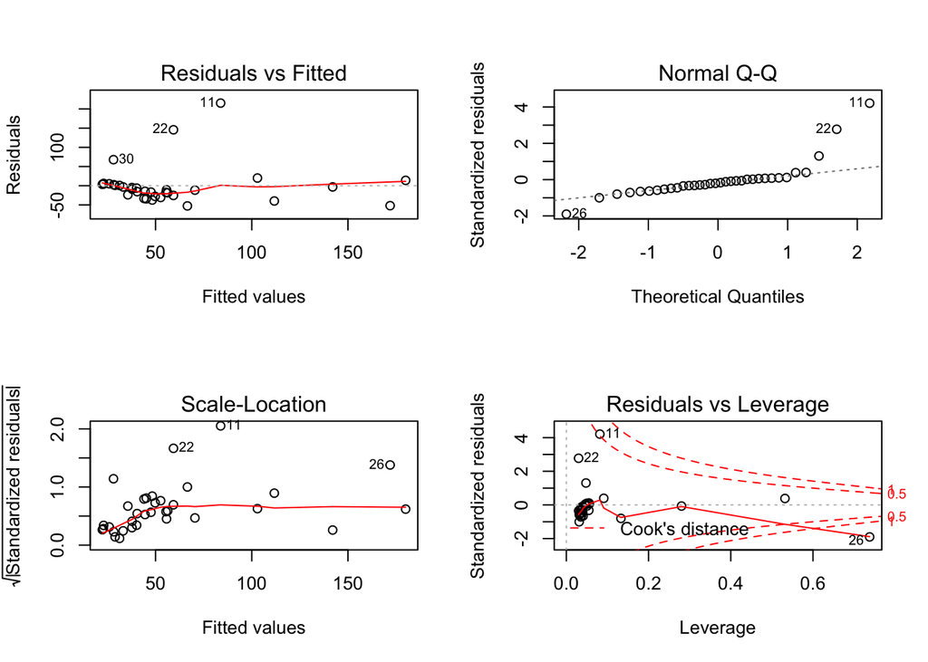

```
##                     2.5 %      97.5 %
## (Intercept) -24.758370656 38.24323282
## TNFa          0.002114188  0.01213612
## LEP           1.086683400  4.12889654
```

The residuals look significantly better here, as do the confidence intervals. Additionally, the confidence intervals on the coefficients do not flip signs, suggesting that these are likely to be useful predictors. TNFa has fairly small coefficients, suggesting that it is not contributing a lot to the model, when compared to the Leptin coefficients.

```
## Start:  AIC=269.96
## ApacheIII ~ TNFa + LEP + IFNG
##
##        Df Sum of Sq    RSS    AIC
## <none>               75437 269.96
## - IFNG  1     12749  88186 273.27
## - TNFa  1     18595  94032 275.45
## - LEP   1     28979 104416 279.01
```

```
##
## Call:
## lm(formula = ApacheIII ~ TNFa + LEP + IFNG, data = sepsisData)
##
## Coefficients:
## (Intercept)         TNFa          LEP         IFNG
##   47.389581     0.006351     2.400800    -0.831062
```

Interestingly, AIC doesn’t want to remove any variables, so apparently adding this predictor improved the model.

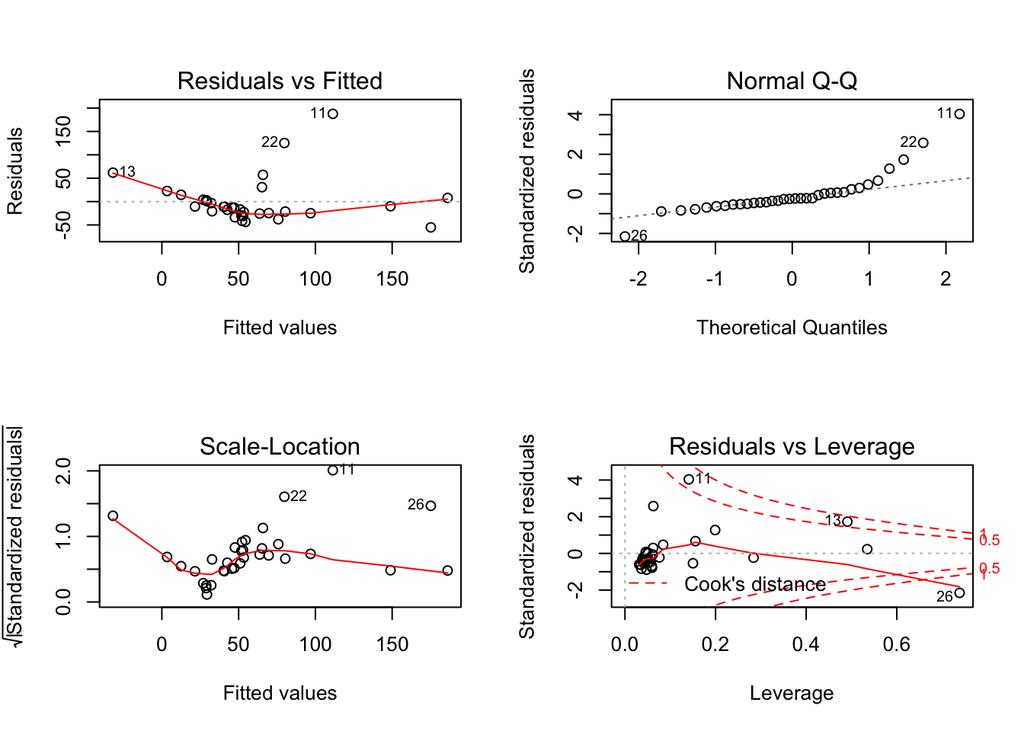

Unfortunately, this model looks worse in terms of residuals.

```
##                    2.5 %      97.5 %
## (Intercept)  0.074729607 94.70443259
## TNFa         0.001581244  0.01112043
## LEP          0.956491282  3.84510798
## IFNG        -1.584836820 -0.07728665
```

These look OK, but I still don’t want to trust predictions from this model about my grandmother’s health if she enters a hospital with sepsis someday (hopefully never).

```
## Analysis of Variance Table
##
## Model 1: ApacheIII ~ TNFa + LEP
## Model 2: ApacheIII ~ CXCL1 + CCL3 + IL10 + IFNG + CCL2
##   Res.Df   RSS Df Sum of Sq      F Pr(>F)
## 1     31 88186
## 2     28 82457  3    5729.7 0.6485 0.5905
```

I think this means there’s no big difference in these two models, but we didn’t really get into ANOVAs yet, so I’m not sure how to interpret this.

```
## Analysis of Variance Table
##
## Model 1: ApacheIII ~ TNFa + LEP
## Model 2: ApacheIII ~ TNFa + LEP + IFNG
##   Res.Df   RSS Df Sum of Sq    F  Pr(>F)
## 1     31 88186
## 2     30 75437  1     12749 5.07 0.03182 *
## ---
## Signif. codes:  0 '***' 0.001 '**' 0.01 '*' 0.05 '.' 0.1 ' ' 1
```

I think this means the fit with the added variable is better, but again, I’m not completly certain how to interpret ANOVA results yet.

It is also possible to check a variety of pairwise correlations between each variable and also the predictive variable of interest.

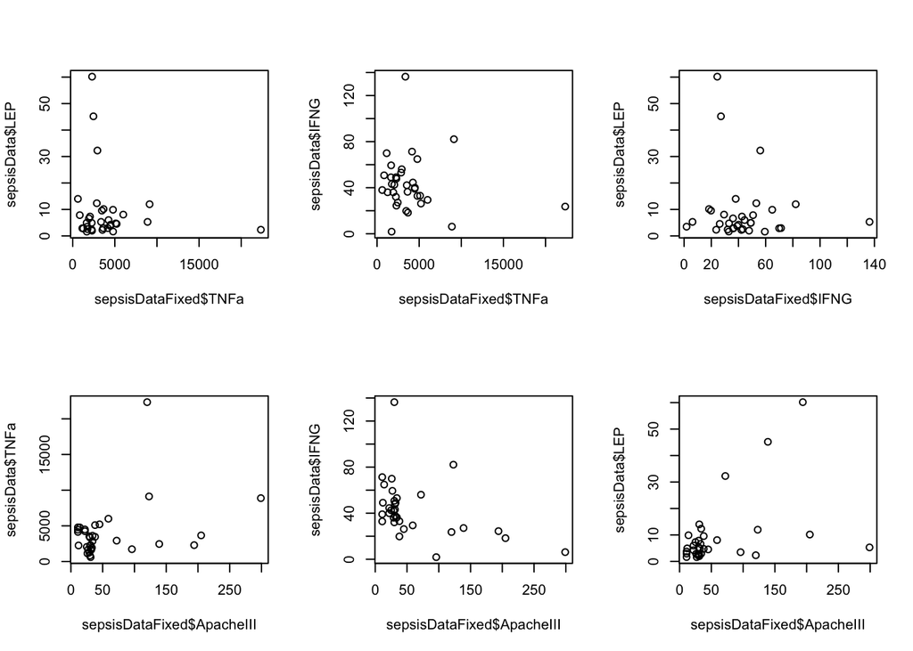

On the first row are plots of each pair of predictors; none of these have particularly striking correlations, which is relatively good news for the stability of the solution that the linear regression derived because the solution should be stable.

On the second row are correlations between each predictive factor and the Apache III variable (indicator of sepsis). None of these are very convincing, which probably means that the Apache III is not a good evaluation of sepsis risk. (This isn’t surprising, given that the measure incorporates a variety of physiological metrics into a single score.)

### Minerva Applied to Sepsis

```
##           ApacheIII  CXCL1   IL1B   CCL3    IL6   TNFa    IL8    LEP
## ApacheIII    0.9975 0.2672 0.4749 0.3309 0.2836 0.4972 0.2906 0.3188
## CXCL1        0.2672 1.0000 0.3459 0.3825 0.2795 0.2920 0.4423 0.3453
## IL1B         0.4749 0.3459 1.0000 0.2781 0.3613 0.2930 0.3198 0.2571
## CCL3         0.3309 0.3825 0.2781 1.0000 0.2996 0.2612 0.3319 0.3348
## IL6          0.2836 0.2795 0.3613 0.2996 1.0000 0.2887 0.2849 0.3572
## TNFa         0.4972 0.2920 0.2930 0.2612 0.2887 1.0000 0.2278 0.3915
## IL8          0.2906 0.4423 0.3198 0.3319 0.2849 0.2278 1.0000 0.4329
## LEP          0.3188 0.3453 0.2571 0.3348 0.3572 0.3915 0.4329 1.0000
## IL10         0.3608 0.4505 0.2583 0.3569 0.2538 0.2485 0.2484 0.3093
## IFNG         0.5474 0.3474 0.2944 0.3669 0.2787 0.3096 0.3074 0.2129
## CCL2         0.2475 0.2414 0.4776 0.1897 0.4669 0.2817 0.3017 0.2216
##             IL10   IFNG   CCL2
## ApacheIII 0.3608 0.5474 0.2475
## CXCL1     0.4505 0.3474 0.2414
## IL1B      0.2583 0.2944 0.4776
## CCL3      0.3569 0.3669 0.1897
## IL6       0.2538 0.2787 0.4669
## TNFa      0.2485 0.3096 0.2817
## IL8       0.2484 0.3074 0.3017
## LEP       0.3093 0.2129 0.2216
## IL10      1.0000 0.3834 0.4402
## IFNG      0.3834 1.0000 0.3265
## CCL2      0.4402 0.3265 1.0000
```

In each table, the entry value correponds to the value indicated in the title above the table, and the relation measured corresponds to the row-column label pair. NA means that the value was outside the range of the lookup table (i.e. not significant). Each table is symmetric.

**MIC P-Values**

```
##           ApacheIII  CXCL1   IL1B CCL3    IL6   TNFa    IL8    LEP   IL10
## ApacheIII        NA     NA 0.0259   NA     NA 0.0167     NA     NA     NA
## CXCL1            NA     NA     NA   NA     NA     NA 0.0535     NA 0.0435
## IL1B         0.0259     NA     NA   NA     NA     NA     NA     NA     NA
## CCL3             NA     NA     NA   NA     NA     NA     NA     NA     NA
## IL6              NA     NA     NA   NA     NA     NA     NA     NA     NA
## TNFa         0.0167     NA     NA   NA     NA     NA     NA     NA     NA
## IL8              NA 0.0535     NA   NA     NA     NA     NA 0.0598     NA
## LEP              NA     NA     NA   NA     NA     NA 0.0598     NA     NA
## IL10             NA 0.0435     NA   NA     NA     NA     NA     NA     NA
## IFNG         0.0058     NA     NA   NA     NA     NA     NA     NA     NA
## CCL2             NA     NA 0.0249   NA 0.0303     NA     NA     NA 0.0544
##             IFNG   CCL2
## ApacheIII 0.0058     NA
## CXCL1         NA     NA
## IL1B          NA 0.0249
## CCL3          NA     NA
## IL6           NA 0.0303
## TNFa          NA     NA
## IL8           NA     NA
## LEP           NA     NA
## IL10          NA 0.0544
## IFNG          NA     NA
## CCL2          NA     NA
```

**MIC 95% CIs**

```
##           ApacheIII CXCL1  IL1B CCL3   IL6 TNFa   IL8   LEP  IL10 IFNG
## ApacheIII        NA    NA 1e-04   NA    NA    0    NA    NA    NA    0
## CXCL1            NA    NA    NA   NA    NA   NA 1e-04    NA 1e-04   NA
## IL1B          1e-04    NA    NA   NA    NA   NA    NA    NA    NA   NA
## CCL3             NA    NA    NA   NA    NA   NA    NA    NA    NA   NA
## IL6              NA    NA    NA   NA    NA   NA    NA    NA    NA   NA
## TNFa          0e+00    NA    NA   NA    NA   NA    NA    NA    NA   NA
## IL8              NA 1e-04    NA   NA    NA   NA    NA 1e-04    NA   NA
## LEP              NA    NA    NA   NA    NA   NA 1e-04    NA    NA   NA
## IL10             NA 1e-04    NA   NA    NA   NA    NA    NA    NA   NA
## IFNG          0e+00    NA    NA   NA    NA   NA    NA    NA    NA   NA
## CCL2             NA    NA 1e-04   NA 1e-04   NA    NA    NA 1e-04   NA
##            CCL2
## ApacheIII    NA
## CXCL1        NA
## IL1B      1e-04
## CCL3         NA
## IL6       1e-04
## TNFa         NA
## IL8          NA
## LEP          NA
## IL10      1e-04
## IFNG         NA
## CCL2         NA
```

# References

Further Reading :

S Nakagawa & IC Cuthill. “Effect size, confidence interval and statistical significance: A practical guide for biologists.” 2007. ISSN 14647931.

BK Slinker & SA Glantz. “Multiple regression for physiological data analysis: the problem of multicolinearity.” *The American Journal of Phsyiology*, 249 (1 Pt 2) R1-R12, 1985 ISSN 0002-9513.

Sepsis Data :

A Elixhauser, B Friedman & E Stranges. “Septicemia in US hospitals, 2009.” *Agency for Healthcare Research and Quality,* 348(62):1-13, 2011.

ApacheIII, Cytokines and Pro-Inflammatory Biomolecules :

http://en.wikipedia.org/wiki/Inflammation http://en.wikipedia.org/wiki/CCL2 http://en.wikipedia.org/wiki/CCL3 http://en.wikipedia.org/wiki/Interferon_gamma http://en.wikipedia.org/wiki/Interleukin_10 http://en.wikipedia.org/wiki/Leptin http://en.wikipedia.org/wiki/Interleukin_8 http://en.wikipedia.org/wiki/Tumor_necrosis_factor_alpha http://en.wikipedia.org/wiki/Interleukin_6 http://en.wikipedia.org/wiki/IL1B http://en.wikipedia.org/wiki/CXCL1 http://www.ncbi.nlm.nih.gov/pubmed/0001959406 http://en.wikipedia.org/wiki/APACHE_II#APACHE_III

Cartoons :

http://www.seykota.com/tribe/FAQ/2004_Jan/Jan_1/recursive.gif

http://mrburkemath.net/xwhy/images/872belle-whiskers05.png

http://xwhy.comicgenesis.com/comics/20100219outliar01.png

Made with R

```
##                _
## platform       x86_64-apple-darwin13.4.0
## arch           x86_64
## os             darwin13.4.0
## system         x86_64, darwin13.4.0
## status
## major          3
## minor          1.3
## year           2015
## month          03
## day            09
## svn rev        67962
## language       R
## version.string R version 3.1.3 (2015-03-09)
## nickname       Smooth Sidewalk
```